# Подготовка к работе с Git и GitHub

# Проверьте наличие Git

Откройте Rstudio. В верхнем меню выберите **Tools → Terminal → New Terminal**. В терминале введите команду `git` и нажмите Enter. Если вы видите результат как на скриншоте ниже, то Git установлен, иначе нужно его установить - см. инструкцию ниже.

[figure not shown]

# Установите Git

Выберите вариант для вашей операционной системы. После установки перезапустите RStudio и повторите проверку.

## Windows

Загрузите инсталлятор по ссылке git-scm.com/downloads/win

Во время установки можно оставить опции выбранные по умолчанию.

## Mac OS

**Вариант 1.** В терминале введите:

```bash
xcode-select --install
```

В появившемся окне нажмите кнопку **Install**.

**Вариант 2.** Если у вас установлен Homebrew, в терминале введите:

```bash
brew install git
```

**Вариант 3.** Установите при помощи **Binary installer** с сайта git-scm.com/downloads/mac

## Linux

Для Ubuntu или Debian:

```bash
sudo apt-get install git
```

Для других дистрибутивов см. git-scm.com/downloads/linux (не забудьте запустить команду с правами администратора, т.е. через `sudo` как в примере выше).

# Настройте Git

В терминале выполните следующие команды заменив на свое имя и email, указанный при регистрации на GitHub.

```bash
git config --global user.name "Your Name"
git config --global user.email "your@email.com"
```

# Создайте токен для GitHub

Для работы с GitHub вам нужно создать так называемый **Personal Access Token** - отдельный многоразовый пароль.

Для этого перейдите по ссылке github.com/settings/tokens, авторизуйтесь и нажмите **Generate new token**, в выпадающем списке выберите **classic**.

На новой странице введите название токена, например Demo. Отметьте следующие права `repo`, `workflow`, `user` и нажмите зеленую кнопку **Generate token** в конце страницы.

Не забудьте скопировать и сохранить ваш токен - он выглядит как строка вида

`ghp_xxxxxxxxxxxxxxxxxxxxxxxxxxxxxxxxxxxx`

После того как вы закроете страницу посмотреть созданный токен невозможно. Храните его в надежном месте как пароль.

[figure not shown]

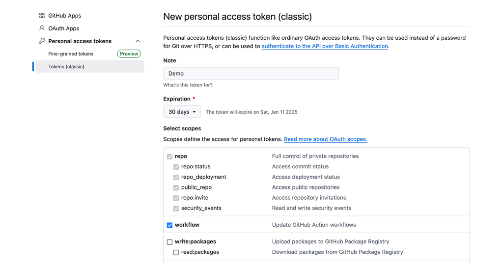

[figure not shown]